# Lecture #14: The Normal Approximation of the Binomial

STAT 200 – Introductory Statistics

Torin Quinlivan

tquinlivan@knox.edu

Knox College

October 27, 2026

## The Meaning of Approximating Distributions

What does it mean for one distribution to “approximate” a different distribution?

The cumulative probabilities are close. That is, if $X_1$ and $X_2$ are from distributions that are “approximately” the same, then for all values of $x$:

$$\mathbb{P}(X_1 \le x) \approx \mathbb{P}(X_2 \le x)$$

Of course, there is a lot of “statistical” detail hidden in the “$\approx$” sign. How close is “close enough”? That is a question of precision. It is left up to the scientist for what precision is needed. Different applications have different needs.

## Approximating the Binomial with the Normal

Let $X_1 \sim \text{Binomial}(n, p)$.

Let $X_2 \sim \text{Normal}(\mu, \sigma^2)$.

To achieve our goals, we would like to determine some rules on $n$, $p$, $\mu$ and $\sigma^2$ to ensure that

$$\mathbb{P}(X_1 \le x) \approx \mathbb{P}(X_2 \le x)$$

## The Binomial Distribution

If $X_1 \sim \text{Binomial}(n, p)$, then:

1. The number of trials, $n$, is known.
2. Each trial has two possible outcomes, “success” and “not success”.
3. The success probability, $p$, does not change from trial to trial.
4. The trials are independent.
5. The random variable is the number of successes in those $n$ trials.

## Approximating the Binomial with the Normal

The definition of the Binomial tells us:

- $\mathbb{E}(X_1) = np$
- $\mathbb{V}(X_1) = np(1-p)$

From this, it is natural to use these parameters to define the approximate Normal distribution.

Let us see how well $X_2 \sim \text{Normal}(\mu = np, \sigma^2 = np(1-p))$ works as an approximation.

## The Binomial PMF

Here is a graphic of the probability mass function (pmf) of the $\text{Binomial}(5, 0.500)$ in red. The pmf provides probabilities for a discrete distribution.

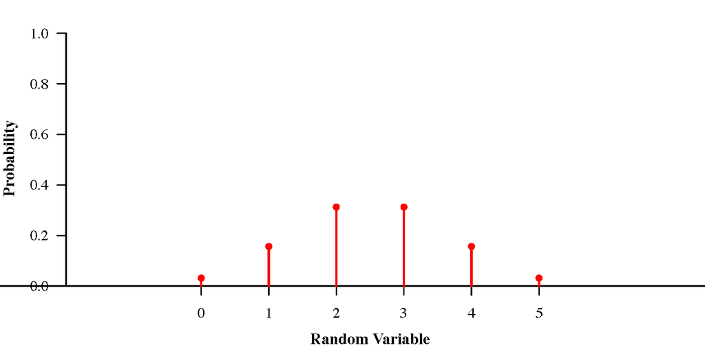

## The Binomial CDF

Here is a graphic of the cumulative distribution function (CDF) of the $\text{Binomial}(5, 0.500)$ in red.

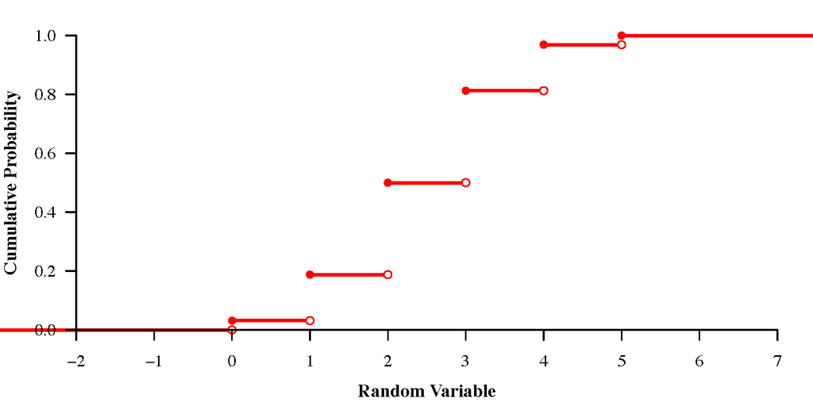

## The Normal CDF

Here is a graphic of the cumulative distribution function (CDF) of the $\text{Normal}(\mu = 2.5, \sigma^2 = 1.25)$ in blue.

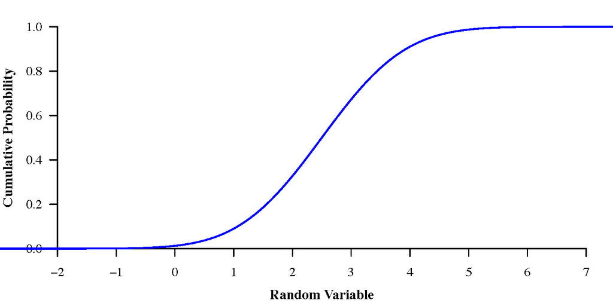

## Comparing the Binomial and Normal CDFs

Here is a graphic of the cumulative distribution function (CDF) of the $\text{Binomial}(5, 0.500)$ in red and of the $\text{Normal}(\mu = 2.5, \sigma^2 = 1.25)$ in blue.

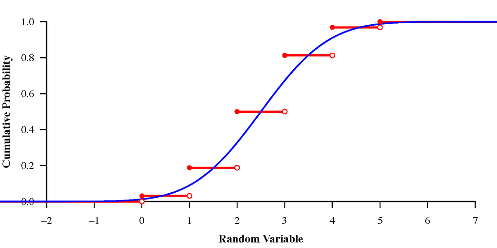

## Illustrating the Effect of Sample Size

What is the effect on increasing the sample size, $n$, while keeping $p = 0.500$ fixed?

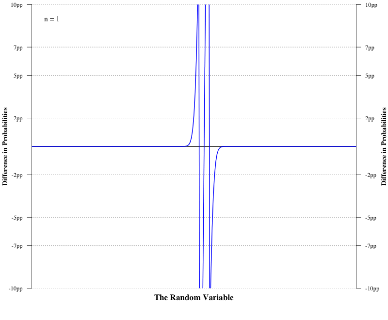

## Several Results and Conclusions

From this brief experiment, we can come to one conclusion: The approximation is better for larger values of $n$.

With additional exploration, we could come to a second conclusion: The approximation is better for values of $p$ close to $0.500$.

Combining these two observations leads to the following “rule of thumb”: The Normal distribution is “sufficiently” close to the Binomial distribution if both the expected number of successes and the expected number of failures are at least 10: $np \ge 10$ and $n(1-p) \ge 10$.

**Note:** The approximation is improved by using a “continuity correction” of $0.500$. (added if $\le$, subtracted if $\ge$, both if $=$).

## Example #1: Cheating

Let us examine a certain Mathematics course taught by a certain professor at a certain midwestern college in the United States. On average, $2\%$ of the students cheat on their examinations, thus making their transcripts all but useless as a means of illustrating their knowledge.

Use the continuity correction factor to estimate the probability that fewer than two students cheat on the midterm in that mathematics course with $50$ students.

In other words, if $X$ is the number of students cheating in the Math midterm examination, and $X \sim \text{Binomial}(50, 0.02)$, then calculate $\mathbb{P}(X < 2)$.

## Example #1: Cheating

First, what is the Normal distribution that best approximates this Binomial?

- $X \sim \text{Binomial}(50, 0.02)$.
- Thus, $\mu = np = 1$ and $\sigma^2 = np(1-p) = 0.98$.
- Then, $X \approx Y$, where $Y \sim \text{Normal}(\mu = 1, \sigma^2 = 0.98)$.

## Example #1: Cheating

Next, we determine the probability statement.

- The problem is asking for $\mathbb{P}(X < 2)$.
- The continuity correction adds and/or subtracts $0.5000$ to the value, **whichever includes the region**.
- Thus, $\mathbb{P}(X < 2) \approx \mathbb{P}(Y \le 1.5)$.

## Example #1: Cheating

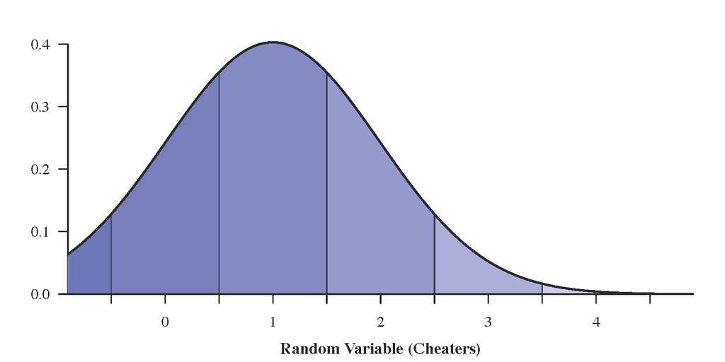

## Example #1: Cheating

Therefore, using the continuity correction, the probability of fewer than two students cheating on their Mathematics test is

```r
pnorm(1.5, mean = 1, sd = sqrt(0.98))
```

```
[1] 0.6932474
```

We can calculate the correct probability using the computer so we can compare how well the approximation did:

```r
pbinom(1, size = 50, prob = 0.02)
```

```
[1] 0.7357714
```

**Note:** Here $np = 1 < 10$, so the rule of thumb is *not* met, and the approximation ($0.693$) is noticeably off from the exact value ($0.736$).

## Example #2: Births

While it is not entirely accurate, for the purposes of this problem, let us assume that the probability of a girl being born is $50\%$. Estimate the probability of more than $55$ girls being born in $100$ births using a continuity correction.

In other words, if $X$ is the number of girls born in those 100 births, and $X \sim \text{Binomial}(100, 0.500)$, then calculate $\mathbb{P}(X > 55)$.

## Example #2: Births

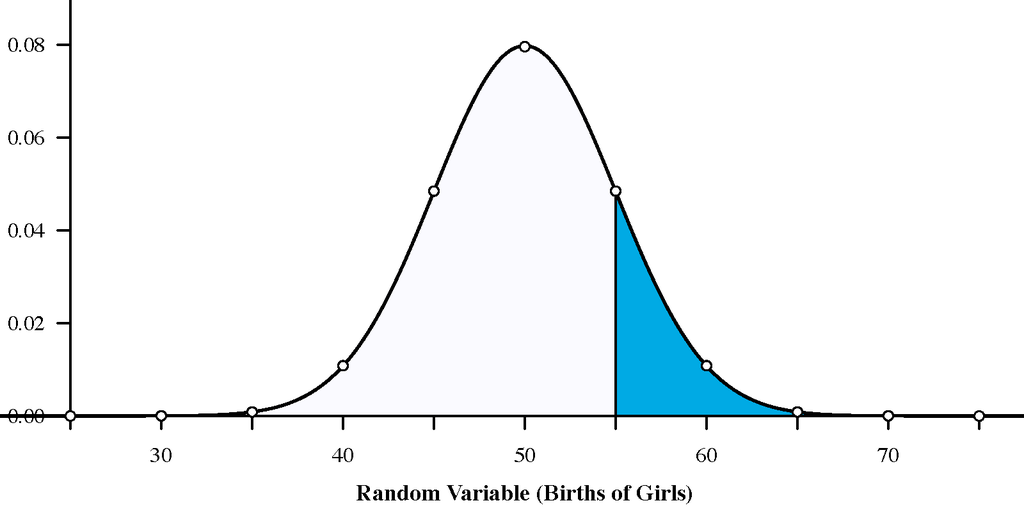

## Example #2: Births

Here are the probability calculations:

$$\begin{aligned}
X &\sim \text{Binomial}(100, 0.500) \\
\Longrightarrow Y &\sim \text{Normal}(\mu = 50, \sigma^2 = 25)
\end{aligned}$$

$$\begin{aligned}
\mathbb{P}(X > 55) &\approx \mathbb{P}(Y \ge 55.5) \\
&= 1 - \mathbb{P}(Y \le 55.5) \\
&= 0.1356661
\end{aligned}$$

Thus, there is about a $13.6\%$ probability that more than $55$ girls will be born in $100$ births.

## Example #2: Births

In `R`, this is:

```r
1 - pnorm(55.5, mean = 50, sd = 5)
```

```
[1] 0.1356661
```

```r
1 - pbinom(55, size = 100, prob = 0.500)
```

```
[1] 0.1356265
```

**Errors:** The absolute error is just $0.00004$, and the relative error is only $0.029\%$.

## Example #3: The Stats Examination

After many hours of studying for your statistics examination, you believe that you have a $90\%$ probability of answering any given question correctly. Your test includes $50$ true/false questions. Assuming that your estimate is the true probability that you will answer any question correctly, use a Normal distribution to estimate the probability that you will miss no more than $4$ questions.

In other words, if $X$ is the number of problems you get **wrong** on this examination, and $X \sim \text{Binomial}(50, 0.100)$, then calculate $\mathbb{P}(X \le 4)$.

## Example #3: The Stats Examination

Here are the probability calculations:

$$\begin{aligned}
X &\sim \text{Binomial}(50, 0.100) \\
\Longrightarrow Y &\sim \text{Normal}(\mu = 5, \sigma^2 = 4.5)
\end{aligned}$$

$$\begin{aligned}
\mathbb{P}(X \le 4) &\approx \mathbb{P}(Y \le 4.5) \\
&= 0.4068319
\end{aligned}$$

Thus, the probability that you miss no more than four problems, or that you will earn at least an A- is $40.7\%$. What is the probability you’ll earn an A?

## Example #3: The Stats Examination

In `R`, this is:

```r
pnorm(4.5, mean = 5, sd = sqrt(4.5))
```

```
[1] 0.4068319
```

```r
pbinom(4, size = 50, prob = 0.100)
```

```
[1] 0.4311984
```

## Example #4: Toothpaste

Many toothpaste commercials advertise that “$3$ out of $4$ dentists recommend their brand of toothpaste.” Use a Normal distribution to estimate the probability that in a random survey of $400$ dentists, exactly $300$ will recommend Brand F toothpaste.

In this calculation, let us assume that the commercials are correct, and therefore, there is a $75\%$ chance that any specific dentist will recommend Brand F toothpaste.

In other words, if $X$ is the number of dentists recommending Brand F toothpaste, and $X \sim \text{Binomial}(400, 0.750)$, then calculate $\mathbb{P}(X = 300)$.

## Example #4: Toothpaste

Here are the probability calculations:

$$\begin{aligned}
X &\sim \text{Binomial}(400, 0.750) \\
\Longrightarrow Y &\sim \text{Normal}(\mu = 300, \sigma^2 = 75)
\end{aligned}$$

$$\begin{aligned}
\mathbb{P}(X = 300) &\approx \mathbb{P}(299.5 <Y \le 300.5) \\
&\approx \mathbb{P}(Y \le 300.5) - \mathbb{P}(Y \le 299.5) \\
&\approx 0.0460403
\end{aligned}$$

Thus, the probability that *exactly* $300$ randomly-selected dentists recommend Brand F toothpaste is approximately $0.0460403$.

## Example #4: Toothpaste

In `R`, this is:

```r
pnorm(300.5, mean = 300, sd = sqrt(75)) - pnorm(299.5, mean = 300, sd = sqrt(75))
```

```
[1] 0.04604031
```

```r
dbinom(300, size = 400, prob = 0.75)
```

```
[1] 0.04602432
```

**Errors:** The absolute error is just $0.000016$, and the relative error is only $0.034\%$.